# Sleep analysis student wellness group

Rajnish Kumar

2024-05-13

```r
library(readxl)
library(dplyr)
library(tidyr)
library(lubridate)
library(Matrix)
library(lme4)
library(lme4)
library(lmerTest)
```

```r
library(ggplot2)
```

Sleep analysis on student wellness group

```r
df_sleep <-read.csv('C:\\Users\\rajnishk\\OneDrive - Michigan Medicine\\Documents\\Student Wellness Dataset\\student_wellness_sleep_details.csv')
df_MOOD <- read.csv('C:\\Users\\rajnishk\\OneDrive - Michigan Medicine\\Documents\\Student Wellness Dataset\\df_MOOD_SWG.csv')
```

```r
#df_ONC <-read.csv('C:\\Users\\rajnishk\\OneDrive - Michigan Medicine\\Desktop\\steps_onc.csv', nrows = 10)
```

```r
df_MOOD <- df_MOOD[df_MOOD$MOOD != 0, ]
df_MOOD <- df_MOOD %>% rename(SLEEP_DATE = METRIC_START_DATE) # So that I can join two data frames later.
# df_MOOD_sleep <- merge(df_sleep, df_MOOD, by = c("STUDY_PRTCPT_ID", "SLEEP_DATE"), all = FALSE)
```

```r
# Define sleep variables
sleep_vars <- c('ASLEEP_VALUE', 'INBED_VALUE', 'DEEP_MIN', 'DEEP_COUNT', 'LIGHT_MIN', 'LIGHT_COUNT',
                'REM_MIN', 'REM_COUNT', 'WAKE_MIN', 'WAKE_COUNT', 'ASLEEP_MIN', 'ASLEEP_COUNT',
                'AWAKE_COUNT', 'AWAKE_MIN', 'RESTLESS_COUNT', 'RESTLESS_MIN')

v <- colSums(is.na(df_sleep[, sleep_vars]))
v <- names(v[v < 500])

vv <- c("STUDY_PRTCPT_ID", "SLEEP_START_DATE", "SLEEP_END_DATE", "SLEEP_DATE", v)
dx <- df_sleep[, vv, drop = FALSE]
```

```r
dx$YEARDAY <- yday(as.Date(dx$SLEEP_DATE))
dx$DAYOFWEEK <- wday(as.Date(dx$SLEEP_DATE), label = FALSE) - 1  # Adjust if week start is Sunday in the given dataset

# Helper function to calculate hours since midnight
hours_since_midnight <- function(time) {
  hour(time) + minute(time) / 60 + second(time) / 3600
}

# Calculate time-related features
dx$SLEEP_START_TIME <- hours_since_midnight(dx$SLEEP_START_DATE)
dx$SLEEP_END_TIME <- hours_since_midnight(dx$SLEEP_END_DATE)

# Apply trigonometric transformations
dx$SLEEP_START_SIN <- sin(2 * pi * dx$SLEEP_START_TIME / 24)
dx$SLEEP_START_COS <- cos(2 * pi * dx$SLEEP_START_TIME / 24)
dx$SLEEP_END_SIN <- sin(2 * pi * dx$SLEEP_END_TIME / 24)
dx$SLEEP_END_COS <- cos(2 * pi * dx$SLEEP_END_TIME / 24)
dx$YEARDAY_SIN <- sin(2 * pi * dx$YEARDAY / 366)
dx$YEARDAY_COS <- cos(2 * pi * dx$YEARDAY / 366)
```

```r
# Calculate STUDYDAY
dx <- dx %>%
  group_by(STUDY_PRTCPT_ID) %>%
  mutate(STUDYDAY = YEARDAY - min(YEARDAY)) %>%
  ungroup()

# Drop unused columns
#dx <- dx %>% select(-c(SLEEP_START_DATE, SLEEP_END_DATE, SLEEP_START_TIME, SLEEP_END_TIME, SLEEP_DATE))
dx <- dx %>% select(-c(SLEEP_START_DATE, SLEEP_END_DATE, SLEEP_START_TIME, SLEEP_END_TIME))


dx <- na.omit(dx) # Dropping rows with NA values

colnames(dx) # Print remaining column names
```

```
##  [1] "STUDY_PRTCPT_ID" "SLEEP_DATE"      "ASLEEP_VALUE"    "INBED_VALUE"
##  [5] "DEEP_MIN"        "DEEP_COUNT"      "LIGHT_MIN"       "LIGHT_COUNT"
##  [9] "REM_MIN"         "REM_COUNT"       "WAKE_MIN"        "WAKE_COUNT"
## [13] "YEARDAY"         "DAYOFWEEK"       "SLEEP_START_SIN" "SLEEP_START_COS"
## [17] "SLEEP_END_SIN"   "SLEEP_END_COS"   "YEARDAY_SIN"     "YEARDAY_COS"
## [21] "STUDYDAY"
```

```r
df_MOOD_sleep_polar <- merge(dx, df_MOOD, by = c("STUDY_PRTCPT_ID", "SLEEP_DATE"), all = FALSE)
df_MOOD_sleep_polar <- df_MOOD_sleep_polar%>% select(-c('STUDY_METRIC_AGGREGATE_ID','METRIC_END_DATE','X','METRIC_END_DATE','STUDY_ID'))
```

```r
columns_for_norm <- c('ASLEEP_VALUE', 'INBED_VALUE', 'DEEP_MIN', 'DEEP_COUNT',
                      'LIGHT_MIN', 'LIGHT_COUNT', 'REM_MIN', 'REM_COUNT',
                      'WAKE_MIN', 'WAKE_COUNT', 'STEP_COUNT', 'SLEEP_COUNT')

df_MOOD_sleep_polar_MOOD_NZ_norm <- df_MOOD_sleep_polar

df_MOOD_sleep_polar_MOOD_NZ_norm[columns_for_norm] <- as.data.frame(lapply(df_MOOD_sleep_polar[columns_for_norm],function(x) {(x - mean(x)) / sd(x)}))
```

INBED_VALUE = ASLEEP_VALUE + WAKE_MIN # This is not true for only two cases for df_MOOD_sleep_polar  
abc <- df_sleep$ASLEEP_VALUE + df_sleep$WAKE_MIN - df_sleep$INBED_VALUE # mostly 0's and NA's df_sleep$ASLEEP_VALUE - df_sleep$DEEP_MIN - df_sleep$LIGHT_MIN - df_sleep$REM_MIN # This is also mostly 0's and NA's, THIS IS TYPE == STEAGES df_sleep$ASLEEP_VALUE + df_sleep$WAKE_MIN - df_sleep$INBED_VALUE # This is also mostly 0’s and NA’s THIS IS TYPE == STAGES

```r
df_sleep_classic <- subset(df_sleep, TYPE == "classic")
df_sleep_stages <- subset (df_sleep, TYPE == "stages")
```

df_sleep_classic$ASLEEP_MIN - df_sleep_classic$ASLEEP_VALUE # This is all 0’s for classic stages. df_sleep_classic$ASLEEP_VALUE + df_sleep_classic$AWAKE_MIN + df_sleep_classic$RESTLESS_MIN- df_sleep_classic$INBED_VALUE # Mostly 0’s except a very few.

```r
# df_sleep_classic$SLEEP_START_DATE  <-as.POSIXct(df_sleep_classic$SLEEP_START_DATE, format = "%Y-%m-%d %H:%M:%S")
# df_sleep_classic$SLEEP_END_DATE <-as.POSIXct(df_sleep_classic$SLEEP_END_DATE, format = "%Y-%m-%d %H:%M:%S")
# df_sleep_stages$SLEEP_START_DATE  <-as.POSIXct(df_sleep_stages$SLEEP_START_DATE, format = "%Y-%m-%d %H:%M:%S")
# df_sleep_stages$SLEEP_END_DATE <-as.POSIXct(df_sleep_stages$SLEEP_END_DATE, format = "%Y-%m-%d %H:%M:%S")
```

```r
# time_diff_classic <- df_sleep_classic$SLEEP_START_DATE - df_sleep_classic$SLEEP_END_DATE
# time_diff_stages <- df_sleep_stages$SLEEP_START_DATE - df_sleep_stages$SLEEP_END_DATE
```

```r
# classic_stages_common_days <- intersect(df_sleep_classic$SLEEP_DATE, df_sleep_stages$SLEEP_DATE)
# print(classic_stages_common_days)
```

participant W7LX2I74 has lots of measurements of sleep.

```r
# df_sleep_classic_W7LX2I74 <- df_sleep_classic%>% filter(STUDY_PRTCPT_ID=='W7LX2I74')
# df_sleep_stage_W7LX2I74 <- df_sleep_stages %>% filter(STUDY_PRTCPT_ID=='W7LX2I74')
# common_classis_stages_W7LX2I74 <- intersect(df_sleep_classic_W7LX2I74$SLEEP_DATE, df_sleep_stage_W7LX2I74$SLEEP_DATE)
```

Doing prediction of MOOD from “stages” type of sleep.

```r
model <- lmer(MOOD ~ SLEEP_END_SIN + SLEEP_END_COS + DEEP_MIN + (1 | STUDY_PRTCPT_ID), data = df_MOOD_sleep_polar_MOOD_NZ_norm)

summary(model)
```

```
## Linear mixed model fit by REML. t-tests use Satterthwaite's method [
## lmerModLmerTest]
## Formula:
## MOOD ~ SLEEP_END_SIN + SLEEP_END_COS + DEEP_MIN + (1 | STUDY_PRTCPT_ID)
##    Data: df_MOOD_sleep_polar_MOOD_NZ_norm
##
## REML criterion at convergence: 1807.6
##
## Scaled residuals:
##     Min      1Q  Median      3Q     Max
## -3.8049 -0.5267  0.0376  0.6403  2.2394
##
## Random effects:
##  Groups          Name        Variance Std.Dev.
##  STUDY_PRTCPT_ID (Intercept) 1.410    1.188
##  Residual                    2.292    1.514
## Number of obs: 478, groups:  STUDY_PRTCPT_ID, 25
##
## Fixed effects:
##                Estimate Std. Error        df t value Pr(>|t|)
## (Intercept)     6.20728    0.31171  37.76848  19.914   <2e-16 ***
## SLEEP_END_SIN   0.45660    0.18884 473.21284   2.418    0.016 *
## SLEEP_END_COS  -0.36595    0.19634 461.67548  -1.864    0.063 .
## DEEP_MIN        0.06704    0.07626 462.93365   0.879    0.380
## ---
## Signif. codes:  0 '***' 0.001 '**' 0.01 '*' 0.05 '.' 0.1 ' ' 1
##
## Correlation of Fixed Effects:
##             (Intr) SLEEP_END_S SLEEP_END_C
## SLEEP_END_S -0.420
## SLEEP_END_C  0.382 -0.180
## DEEP_MIN     0.113 -0.028       0.325
```

```r
confint(model)
```

```
## Computing profile confidence intervals ...
```

```
##                     2.5 %     97.5 %
## .sig01         0.80851616 1.67851461
## .sigma         1.41592756 1.61334023
## (Intercept)    5.59672219 6.82682869
## SLEEP_END_SIN  0.08787104 0.82693833
## SLEEP_END_COS -0.75058746 0.01801498
## DEEP_MIN      -0.08199129 0.21658153
```

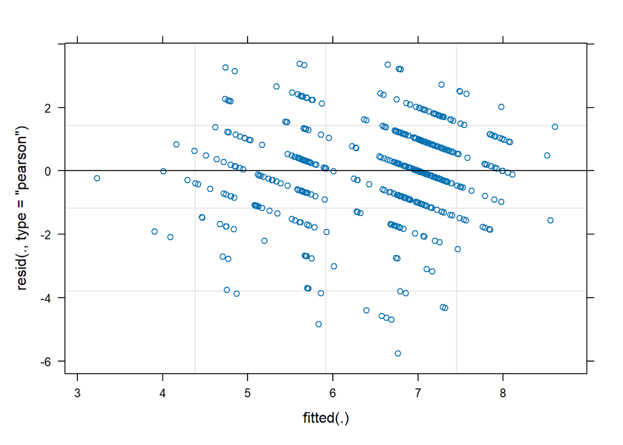

```r
par(mfrow=c(2,2))
plot(model)
```

```r
residuals4 <- residuals(model)
fitted_values <- fitted(model)
```

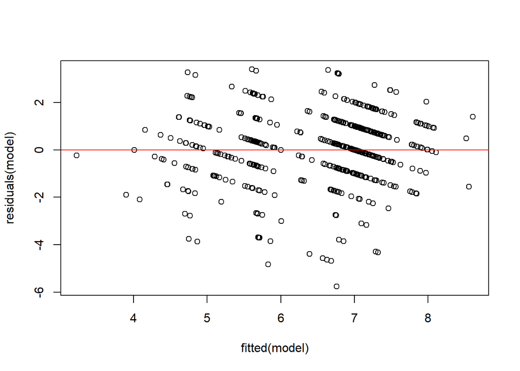

```r
# Alternatively, you can create each diagnostic plot separately:
# Residuals vs Fitted
plot(residuals(model) ~ fitted(model))
abline(h = 0, col = "red")
```

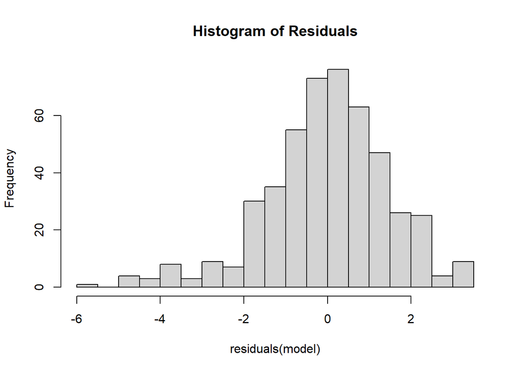

```r
# Histogram of Residuals
hist(residuals(model), breaks = "FD", main = "Histogram of Residuals")
```

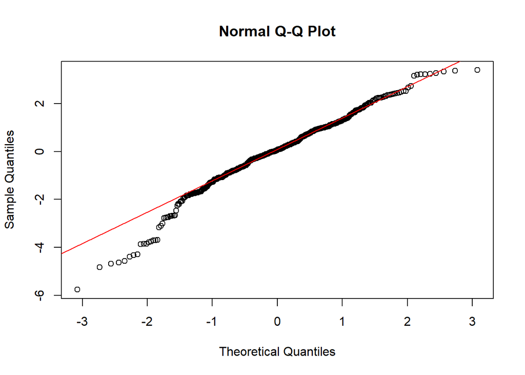

```r
# Q-Q Plot of Residuals
qqnorm(residuals(model))
qqline(residuals(model), col = "red")
```

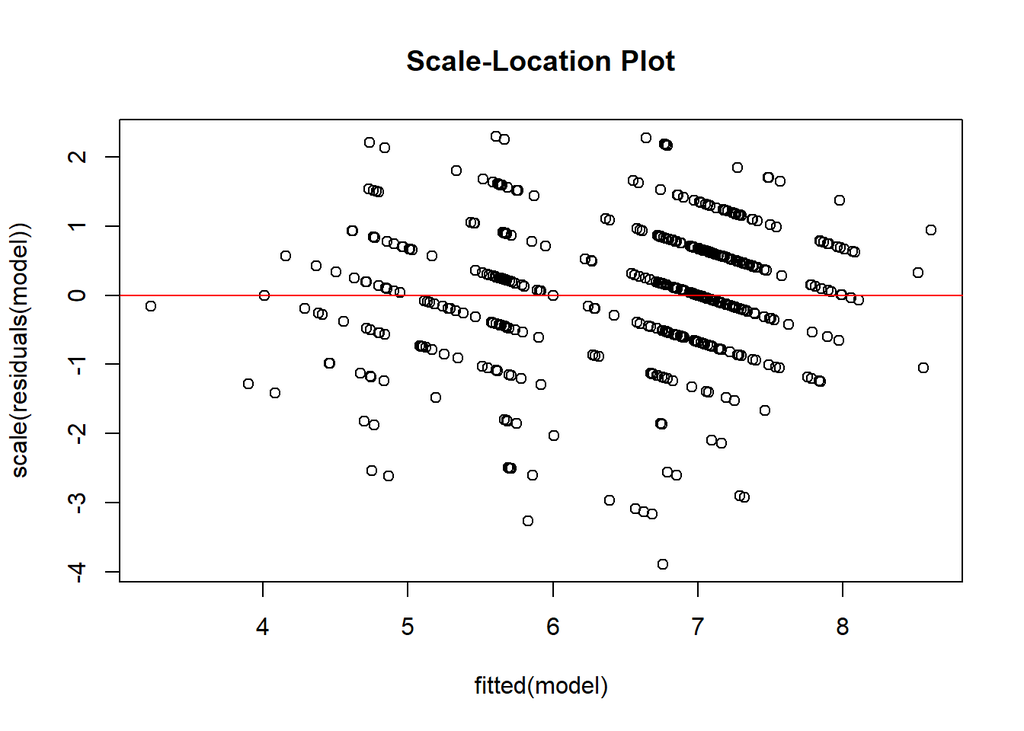

```r
# Scale-Location Plot (Spread vs Level)
plot(fitted(model), scale(residuals(model)), main = "Scale-Location Plot")
abline(h = 0, col = "red")
```

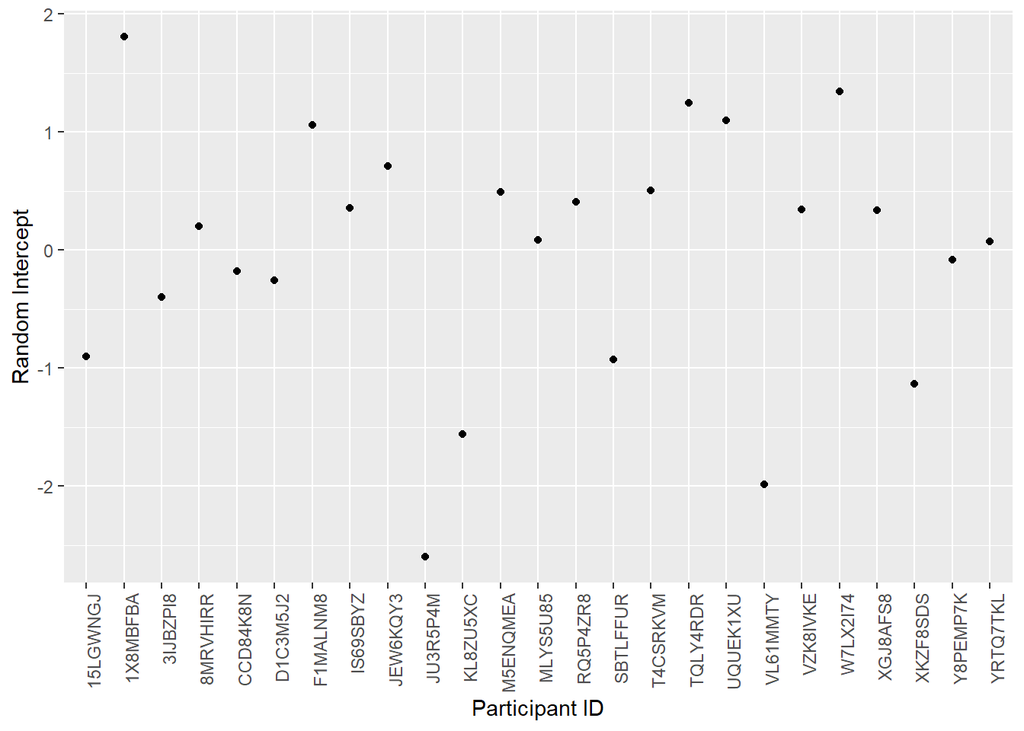

```r
library(ggplot2)

# Extracting random effects
re <- ranef(model)$STUDY_PRTCPT_ID

# Adding participant ID as a column
re$ID <- rownames(re)

# Basic random effects plot
ggplot(re, aes(x = ID, y = `(Intercept)`)) +
  geom_point() +
  theme(axis.text.x = element_text(angle = 90, hjust = 1)) +
  xlab("Participant ID") +
  ylab("Random Intercept")
```

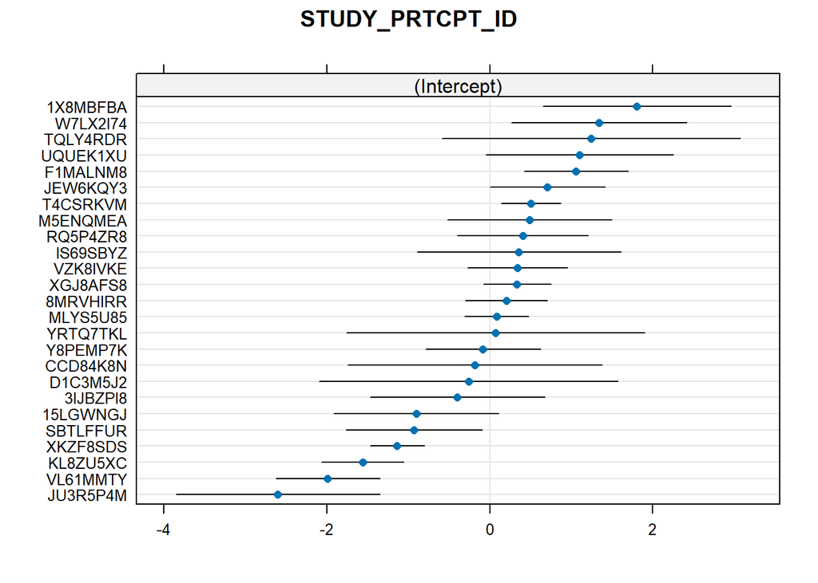

```r
# Alternatively, you can use `dotplot` from `lattice` package
library(lattice)
dotplot(ranef(model, condVar = TRUE))
```

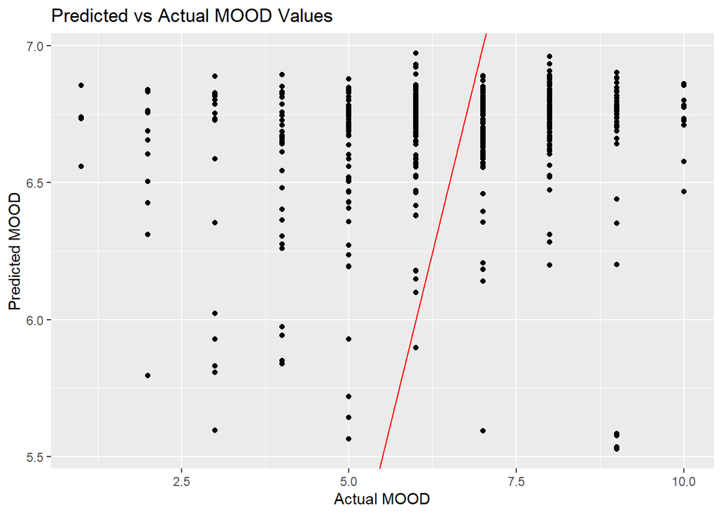

```r
# Assuming that MOOD is a column in your data frame with actual values
df_MOOD_sleep_polar_MOOD_NZ_norm$predicted_MOOD <- predict(model, re.form = NA)

ggplot(df_MOOD_sleep_polar_MOOD_NZ_norm, aes(x = MOOD, y = predicted_MOOD)) +
  geom_point() +
  geom_abline(intercept = 0, slope = 1, color = "red") +
  xlab("Actual MOOD") +
  ylab("Predicted MOOD") +
  ggtitle("Predicted vs Actual MOOD Values")
```

```r
model_lm <- lm( formula = MOOD ~ SLEEP_END_SIN  + SLEEP_END_COS + DEEP_MIN , data = df_MOOD_sleep_polar_MOOD_NZ_norm)

summary(model_lm)
```

```
##
## Call:
## lm(formula = MOOD ~ SLEEP_END_SIN + SLEEP_END_COS + DEEP_MIN,
##     data = df_MOOD_sleep_polar_MOOD_NZ_norm)
##
## Residuals:
##     Min      1Q  Median      3Q     Max
## -5.7882 -0.8070  0.2837  1.3156  4.2083
##
## Coefficients:
##               Estimate Std. Error t value Pr(>|t|)
## (Intercept)    5.83140    0.19630  29.707  < 2e-16 ***
## SLEEP_END_SIN  0.74978    0.18860   3.976 8.12e-05 ***
## SLEEP_END_COS -0.43009    0.21491  -2.001   0.0459 *
## DEEP_MIN       0.11826    0.08631   1.370   0.1713
## ---
## Signif. codes:  0 '***' 0.001 '**' 0.01 '*' 0.05 '.' 0.1 ' ' 1
##
## Residual standard error: 1.783 on 474 degrees of freedom
## Multiple R-squared:  0.04253,    Adjusted R-squared:  0.03647
## F-statistic: 7.019 on 3 and 474 DF,  p-value: 0.000126
```

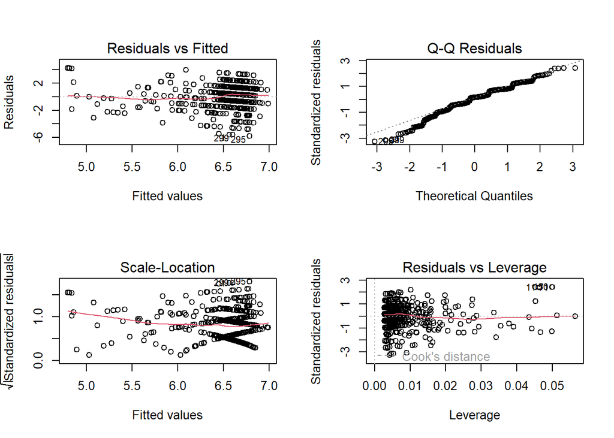

```r
par(mfrow=c(2,2))
plot(model_lm)
```

```r
residuals4 <- residuals(model_lm)
fitted_values <- fitted(model_lm)
```

```r
model1 <- lmer(MOOD ~ SLEEP_COUNT + STEP_COUNT + (1 | STUDY_PRTCPT_ID), data = df_MOOD_sleep_polar_MOOD_NZ_norm)

summary(model1)
```

```
## Linear mixed model fit by REML. t-tests use Satterthwaite's method [
## lmerModLmerTest]
## Formula: MOOD ~ SLEEP_COUNT + STEP_COUNT + (1 | STUDY_PRTCPT_ID)
##    Data: df_MOOD_sleep_polar_MOOD_NZ_norm
##
## REML criterion at convergence: 1798.3
##
## Scaled residuals:
##     Min      1Q  Median      3Q     Max
## -3.8097 -0.5511  0.0289  0.6388  2.3695
##
## Random effects:
##  Groups          Name        Variance Std.Dev.
##  STUDY_PRTCPT_ID (Intercept) 1.519    1.233
##  Residual                    2.234    1.495
## Number of obs: 478, groups:  STUDY_PRTCPT_ID, 25
##
## Fixed effects:
##              Estimate Std. Error        df t value Pr(>|t|)
## (Intercept)   6.70263    0.27470  20.96029  24.399  < 2e-16 ***
## SLEEP_COUNT   0.02293    0.08233 468.29592   0.279    0.781
## STEP_COUNT    0.37529    0.08560 474.96722   4.384 1.43e-05 ***
## ---
## Signif. codes:  0 '***' 0.001 '**' 0.01 '*' 0.05 '.' 0.1 ' ' 1
##
## Correlation of Fixed Effects:
##             (Intr) SLEEP_
## SLEEP_COUNT 0.082
## STEP_COUNT  0.041  0.225
```

```r
confint(model1)
```

```
## Computing profile confidence intervals ...
```

```
##                  2.5 %    97.5 %
## .sig01       0.8506174 1.7343022
## .sigma       1.3995127 1.5945471
## (Intercept)  6.1600099 7.2597587
## SLEEP_COUNT -0.1385284 0.1840600
## STEP_COUNT   0.2070418 0.5424981
```

```r
# par(mfrow=c(2,2))
# plot(model1)
# residuals4 <- residuals(model1)
# fitted_values <- fitted(model1)
```

```r
model_upto_2_interact <- lmer(MOOD ~ (DEEP_MIN + LIGHT_MIN + REM_MIN + WAKE_MIN)^2 + (1 | STUDY_PRTCPT_ID), data = df_MOOD_sleep_polar_MOOD_NZ_norm)
summary(model_upto_2_interact)
```

```
## Linear mixed model fit by REML. t-tests use Satterthwaite's method [
## lmerModLmerTest]
## Formula:
## MOOD ~ (DEEP_MIN + LIGHT_MIN + REM_MIN + WAKE_MIN)^2 + (1 | STUDY_PRTCPT_ID)
##    Data: df_MOOD_sleep_polar_MOOD_NZ_norm
##
## REML criterion at convergence: 1828.1
##
## Scaled residuals:
##     Min      1Q  Median      3Q     Max
## -4.0093 -0.5227  0.0563  0.6104  2.2463
##
## Random effects:
##  Groups          Name        Variance Std.Dev.
##  STUDY_PRTCPT_ID (Intercept) 1.410    1.188
##  Residual                    2.306    1.519
## Number of obs: 478, groups:  STUDY_PRTCPT_ID, 25
##
## Fixed effects:
##                     Estimate Std. Error        df t value Pr(>|t|)
## (Intercept)          6.77469    0.27352  21.71635  24.768   <2e-16 ***
## DEEP_MIN             0.08622    0.09357 455.54955   0.921   0.3573
## LIGHT_MIN           -0.17692    0.12928 466.93157  -1.368   0.1718
## REM_MIN              0.08080    0.10321 462.30840   0.783   0.4341
## WAKE_MIN             0.05337    0.12993 466.84840   0.411   0.6814
## DEEP_MIN:LIGHT_MIN   0.22689    0.12044 454.32168   1.884   0.0602 .
## DEEP_MIN:REM_MIN    -0.05754    0.08258 453.71473  -0.697   0.4863
## DEEP_MIN:WAKE_MIN   -0.13508    0.10723 453.05939  -1.260   0.2084
## LIGHT_MIN:REM_MIN   -0.12109    0.11235 450.23418  -1.078   0.2817
## LIGHT_MIN:WAKE_MIN  -0.06773    0.06082 466.30142  -1.114   0.2660
## REM_MIN:WAKE_MIN    -0.02901    0.10796 450.43242  -0.269   0.7883
## ---
## Signif. codes:  0 '***' 0.001 '**' 0.01 '*' 0.05 '.' 0.1 ' ' 1
##
## Correlation of Fixed Effects:
##             (Intr) DEEP_MIN LIGHT_MIN REM_MIN WAKE_M DEEP_MIN:L DEEP_MIN:R
## DEEP_MIN    -0.034
## LIGHT_MIN    0.043  0.029
## REM_MIN      0.014 -0.425   -0.218
## WAKE_MIN     0.036 -0.251   -0.571    -0.115
## DEEP_MIN:LI  0.104 -0.112    0.094     0.144   0.058
## DEEP_MIN:RE -0.127 -0.184    0.014     0.013   0.070 -0.330
## DEEP_MIN:WA -0.047  0.089   -0.011    -0.052  -0.061 -0.588     -0.126
## LIGHT_MIN:R -0.009  0.154   -0.124    -0.205   0.169 -0.365     -0.022
## LIGHT_MIN:W -0.163  0.064   -0.109     0.133  -0.235 -0.212      0.208
## REM_MIN:WAK -0.012  0.039    0.164    -0.041  -0.144  0.302     -0.148
##             DEEP_MIN:W LIGHT_MIN:R LIGHT_MIN:W
## DEEP_MIN
## LIGHT_MIN
## REM_MIN
## WAKE_MIN
## DEEP_MIN:LI
## DEEP_MIN:RE
## DEEP_MIN:WA
## LIGHT_MIN:R  0.384
## LIGHT_MIN:W -0.232     -0.193
## REM_MIN:WAK -0.346     -0.780       0.170
```

```r
confint(model_upto_2_interact)
```

```
## Computing profile confidence intervals ...
```

```
##                           2.5 %     97.5 %
## .sig01              0.801800003 1.68219360
## .sigma              1.409401323 1.60610290
## (Intercept)         6.233777814 7.32111986
## DEEP_MIN           -0.095192179 0.26858168
## LIGHT_MIN          -0.427409255 0.07550668
## REM_MIN            -0.119226373 0.28206156
## WAKE_MIN           -0.201842614 0.30529732
## DEEP_MIN:LIGHT_MIN -0.006602525 0.46164353
## DEEP_MIN:REM_MIN   -0.218569051 0.10253619
## DEEP_MIN:WAKE_MIN  -0.344307432 0.07275828
## LIGHT_MIN:REM_MIN  -0.339558897 0.09700688
## LIGHT_MIN:WAKE_MIN -0.187275593 0.05021951
## REM_MIN:WAKE_MIN   -0.238197776 0.18231120
```

```r
# par(mfrow=c(2,2))
# plot(model_upto_2_interact)
# residuals_upto_2_interact <- residuals(model_upto_2_interact)
# fitted_values_upto_2_interact <- fitted(model_upto_2_interact)
```

```r
model_upto_2_interact_selected <- lmer(MOOD ~ (LIGHT_MIN + WAKE_MIN )^2 + (1 | STUDY_PRTCPT_ID), data = df_MOOD_sleep_polar_MOOD_NZ_norm)
summary(model_upto_2_interact_selected)
```

```
## Linear mixed model fit by REML. t-tests use Satterthwaite's method [
## lmerModLmerTest]
## Formula: MOOD ~ (LIGHT_MIN + WAKE_MIN)^2 + (1 | STUDY_PRTCPT_ID)
##    Data: df_MOOD_sleep_polar_MOOD_NZ_norm
##
## REML criterion at convergence: 1817.4
##
## Scaled residuals:
##     Min      1Q  Median      3Q     Max
## -3.9483 -0.5313  0.0847  0.6333  2.2285
##
## Random effects:
##  Groups          Name        Variance Std.Dev.
##  STUDY_PRTCPT_ID (Intercept) 1.406    1.186
##  Residual                    2.325    1.525
## Number of obs: 478, groups:  STUDY_PRTCPT_ID, 25
##
## Fixed effects:
##                     Estimate Std. Error        df t value Pr(>|t|)
## (Intercept)          6.70174    0.26946  21.37977  24.871   <2e-16 ***
## LIGHT_MIN           -0.16028    0.12274 473.81680  -1.306    0.192
## WAKE_MIN             0.11980    0.11858 473.99910   1.010    0.313
## LIGHT_MIN:WAKE_MIN  -0.06691    0.05009 473.51205  -1.336    0.182
## ---
## Signif. codes:  0 '***' 0.001 '**' 0.01 '*' 0.05 '.' 0.1 ' ' 1
##
## Correlation of Fixed Effects:
##             (Intr) LIGHT_MIN WAKE_M
## LIGHT_MIN    0.051
## WAKE_MIN     0.022 -0.693
## LIGHT_MIN:W -0.157 -0.049    -0.174
```

```r
confint(model_upto_2_interact_selected)
```

```
## Computing profile confidence intervals ...
```

```
##                         2.5 %     97.5 %
## .sig01              0.8076842 1.67512138
## .sigma              1.4260931 1.62488156
## (Intercept)         6.1670723 7.24169746
## LIGHT_MIN          -0.3996037 0.08194713
## WAKE_MIN           -0.1147263 0.35102993
## LIGHT_MIN:WAKE_MIN -0.1669095 0.03095914
```

```r
model_upto_2_interact_selected <- lmer(MOOD ~ (DEEP_MIN + REM_MIN )^2 + (1 | STUDY_PRTCPT_ID), data = df_MOOD_sleep_polar_MOOD_NZ_norm)
summary(model_upto_2_interact_selected)
```

```
## Linear mixed model fit by REML. t-tests use Satterthwaite's method [
## lmerModLmerTest]
## Formula: MOOD ~ (DEEP_MIN + REM_MIN)^2 + (1 | STUDY_PRTCPT_ID)
##    Data: df_MOOD_sleep_polar_MOOD_NZ_norm
##
## REML criterion at convergence: 1818.6
##
## Scaled residuals:
##     Min      1Q  Median      3Q     Max
## -3.8671 -0.5582  0.0618  0.6467  2.2574
##
## Random effects:
##  Groups          Name        Variance Std.Dev.
##  STUDY_PRTCPT_ID (Intercept) 1.481    1.217
##  Residual                    2.324    1.525
## Number of obs: 478, groups:  STUDY_PRTCPT_ID, 25
##
## Fixed effects:
##                   Estimate Std. Error        df t value Pr(>|t|)
## (Intercept)        6.68000    0.27420  20.97550  24.362   <2e-16 ***
## DEEP_MIN           0.13752    0.08449 458.90528   1.628    0.104
## REM_MIN           -0.05312    0.08791 467.37257  -0.604    0.546
## DEEP_MIN:REM_MIN  -0.03637    0.06498 461.05339  -0.560    0.576
## ---
## Signif. codes:  0 '***' 0.001 '**' 0.01 '*' 0.05 '.' 0.1 ' ' 1
##
## Correlation of Fixed Effects:
##             (Intr) DEEP_MIN REM_MI
## DEEP_MIN    -0.005
## REM_MIN      0.031 -0.505
## DEEP_MIN:RE -0.133 -0.112    0.061
```

```r
confint(model_upto_2_interact_selected)
```

```
## Computing profile confidence intervals ...
```

```
##                        2.5 %     97.5 %
## .sig01            0.83014024 1.71986219
## .sigma            1.42574789 1.62457322
## (Intercept)       6.13612356 7.23269661
## DEEP_MIN         -0.02811971 0.30267652
## REM_MIN          -0.22461980 0.12070399
## DEEP_MIN:REM_MIN -0.16359111 0.09078086
```

```r
model_upto_2_interact_selected <- lmer(MOOD ~ (DEEP_MIN + REM_MIN + ASLEEP_VALUE)^2 + (1 | STUDY_PRTCPT_ID), data = df_MOOD_sleep_polar_MOOD_NZ_norm)
summary(model_upto_2_interact_selected)
```

```
## Linear mixed model fit by REML. t-tests use Satterthwaite's method [
## lmerModLmerTest]
## Formula: MOOD ~ (DEEP_MIN + REM_MIN + ASLEEP_VALUE)^2 + (1 | STUDY_PRTCPT_ID)
##    Data: df_MOOD_sleep_polar_MOOD_NZ_norm
##
## REML criterion at convergence: 1820.6
##
## Scaled residuals:
##     Min      1Q  Median      3Q     Max
## -3.9764 -0.5232  0.0569  0.6053  2.2457
##
## Random effects:
##  Groups          Name        Variance Std.Dev.
##  STUDY_PRTCPT_ID (Intercept) 1.450    1.204
##  Residual                    2.308    1.519
## Number of obs: 478, groups:  STUDY_PRTCPT_ID, 25
##
## Fixed effects:
##                        Estimate Std. Error        df t value Pr(>|t|)
## (Intercept)             6.69012    0.27277  21.49143  24.527   <2e-16 ***
## DEEP_MIN                0.18144    0.10018 463.69123   1.811   0.0708 .
## REM_MIN                 0.16678    0.12467 470.57852   1.338   0.1816
## ASLEEP_VALUE           -0.26838    0.14181 470.99980  -1.893   0.0590 .
## DEEP_MIN:REM_MIN       -0.06606    0.10979 457.68948  -0.602   0.5477
## DEEP_MIN:ASLEEP_VALUE   0.08698    0.10592 460.16551   0.821   0.4120
## REM_MIN:ASLEEP_VALUE   -0.09975    0.05999 455.83265  -1.663   0.0970 .
## ---
## Signif. codes:  0 '***' 0.001 '**' 0.01 '*' 0.05 '.' 0.1 ' ' 1
##
## Correlation of Fixed Effects:
##             (Intr) DEEP_MIN REM_MIN ASLEEP DEEP_MIN:R DEEP_MIN:A
## DEEP_MIN    -0.031
## REM_MIN      0.027 -0.092
## ASLEEP_VALU  0.018 -0.467   -0.630
## DEEP_MIN:RE -0.017 -0.173   -0.029   0.104
## DEEP_MIN:AS -0.046 -0.044    0.126   0.013 -0.717
## REM_MIN:ASL -0.068  0.257   -0.340   0.039 -0.270     -0.107
```

```r
confint(model_upto_2_interact_selected)
```

```
## Computing profile confidence intervals ...
```

```
##                             2.5 %      97.5 %
## .sig01                 0.82327179 1.700067252
## .sigma                 1.41619308 1.613625522
## (Intercept)            6.15032908 7.238842310
## DEEP_MIN              -0.01375352 0.377135327
## REM_MIN               -0.07577313 0.411989971
## ASLEEP_VALUE          -0.54648923 0.007499013
## DEEP_MIN:REM_MIN      -0.27992967 0.148572682
## DEEP_MIN:ASLEEP_VALUE -0.12077824 0.293089168
## REM_MIN:ASLEEP_VALUE  -0.21661263 0.017538812
```

```r
model_upto_2_interact_selected <- lmer(MOOD ~ (DEEP_MIN + REM_MIN + ASLEEP_VALUE + SLEEP_START_SIN + SLEEP_START_COS + STEP_COUNT)^2 + (1 | STUDY_PRTCPT_ID), data = df_MOOD_sleep_polar_MOOD_NZ_norm)
summary(model_upto_2_interact_selected)
```

```
## Linear mixed model fit by REML. t-tests use Satterthwaite's method [
## lmerModLmerTest]
## Formula: MOOD ~ (DEEP_MIN + REM_MIN + ASLEEP_VALUE + SLEEP_START_SIN +
##     SLEEP_START_COS + STEP_COUNT)^2 + (1 | STUDY_PRTCPT_ID)
##    Data: df_MOOD_sleep_polar_MOOD_NZ_norm
##
## REML criterion at convergence: 1814.9
##
## Scaled residuals:
##     Min      1Q  Median      3Q     Max
## -3.7910 -0.5265  0.0306  0.6369  2.2707
##
## Random effects:
##  Groups          Name        Variance Std.Dev.
##  STUDY_PRTCPT_ID (Intercept) 1.393    1.180
##  Residual                    2.242    1.497
## Number of obs: 478, groups:  STUDY_PRTCPT_ID, 25
##
## Fixed effects:
##                                   Estimate Std. Error         df t value
## (Intercept)                       5.919576   0.454933 134.821592  13.012
## DEEP_MIN                         -0.164476   0.255649 440.784064  -0.643
## REM_MIN                           0.008658   0.311784 455.656407   0.028
## ASLEEP_VALUE                     -0.171174   0.415349 453.521688  -0.412
## SLEEP_START_SIN                  -0.266246   0.295967 453.610787  -0.900
## SLEEP_START_COS                   0.800928   0.408075 452.657656   1.963
## STEP_COUNT                        0.336538   0.202672 444.249189   1.661
## DEEP_MIN:REM_MIN                 -0.106548   0.114122 442.297494  -0.934
## DEEP_MIN:ASLEEP_VALUE             0.134030   0.124752 447.767872   1.074
## DEEP_MIN:SLEEP_START_SIN          0.229395   0.204475 444.299901   1.122
## DEEP_MIN:SLEEP_START_COS          0.360564   0.295355 442.167461   1.221
## DEEP_MIN:STEP_COUNT              -0.072131   0.094411 439.485058  -0.764
## REM_MIN:ASLEEP_VALUE             -0.066546   0.070729 446.735111  -0.941
## REM_MIN:SLEEP_START_SIN           0.078913   0.255115 454.471513   0.309
## REM_MIN:SLEEP_START_COS           0.165481   0.364765 455.220473   0.454
## REM_MIN:STEP_COUNT                0.071001   0.116827 449.990980   0.608
## ASLEEP_VALUE:SLEEP_START_SIN     -0.467832   0.272066 453.924828  -1.720
## ASLEEP_VALUE:SLEEP_START_COS      0.000187   0.476928 452.346218   0.000
## ASLEEP_VALUE:STEP_COUNT           0.030835   0.130865 451.804915   0.236
## SLEEP_START_SIN:SLEEP_START_COS   0.886217   0.424928 448.563583   2.086
```

[output cut: 12 more lines]

```
## DEEP_MIN:SLEEP_START_SIN          0.2625
## DEEP_MIN:SLEEP_START_COS          0.2228
## DEEP_MIN:STEP_COUNT               0.4453
## REM_MIN:ASLEEP_VALUE              0.3473
## REM_MIN:SLEEP_START_SIN           0.7572
## REM_MIN:SLEEP_START_COS           0.6503
## REM_MIN:STEP_COUNT                0.5437
## ASLEEP_VALUE:SLEEP_START_SIN      0.0862 .
## ASLEEP_VALUE:SLEEP_START_COS      0.9997
## ASLEEP_VALUE:STEP_COUNT           0.8138
## SLEEP_START_SIN:SLEEP_START_COS   0.0376 *
## SLEEP_START_SIN:STEP_COUNT        0.9314
## SLEEP_START_COS:STEP_COUNT        0.9345
## ---
## Signif. codes:  0 '***' 0.001 '**' 0.01 '*' 0.05 '.' 0.1 ' ' 1
```

```
##
## Correlation matrix not shown by default, as p = 22 > 12.
## Use print(x, correlation=TRUE)  or
##     vcov(x)        if you need it
```

```r
confint(model_upto_2_interact_selected)
```

```
## Computing profile confidence intervals ...
```

```
##                                       2.5 %     97.5 %
## .sig01                           0.79425775 1.66532745
## .sigma                           1.37266755 1.56429691
## (Intercept)                      5.04661384 6.79422527
## DEEP_MIN                        -0.65679954 0.32555445
## REM_MIN                         -0.59163316 0.60633698
## ASLEEP_VALUE                    -0.96742985 0.62930303
## SLEEP_START_SIN                 -0.83814935 0.30148046
## SLEEP_START_COS                  0.01679416 1.58323443
## STEP_COUNT                      -0.05215526 0.72581434
## DEEP_MIN:REM_MIN                -0.32543865 0.11262993
## DEEP_MIN:ASLEEP_VALUE           -0.10635367 0.37316263
## DEEP_MIN:SLEEP_START_SIN        -0.16361813 0.62143442
## DEEP_MIN:SLEEP_START_COS        -0.20559183 0.93004624
## DEEP_MIN:STEP_COUNT             -0.25397230 0.10883576
## REM_MIN:ASLEEP_VALUE            -0.20212128 0.06970327
## REM_MIN:SLEEP_START_SIN         -0.41280098 0.57719607
## REM_MIN:SLEEP_START_COS         -0.53395363 0.86889992
## REM_MIN:STEP_COUNT              -0.15503438 0.29514553
## ASLEEP_VALUE:SLEEP_START_SIN    -0.99534554 0.05468934
## ASLEEP_VALUE:SLEEP_START_COS    -0.92053607 0.91477737
## ASLEEP_VALUE:STEP_COUNT         -0.22008965 0.28336173
## SLEEP_START_SIN:SLEEP_START_COS  0.07169809 1.70483880
## SLEEP_START_SIN:STEP_COUNT      -0.32670667 0.35564962
## SLEEP_START_COS:STEP_COUNT      -0.45107843 0.41228439
```

```r
model_upto_2_interact_selected <- lmer(MOOD ~ (DEEP_MIN + REM_MIN +  SLEEP_START_SIN + SLEEP_START_COS)^2 + (1 | STUDY_PRTCPT_ID), data = df_MOOD_sleep_polar_MOOD_NZ_norm)
summary(model_upto_2_interact_selected)
```

```
## Linear mixed model fit by REML. t-tests use Satterthwaite's method [
## lmerModLmerTest]
## Formula: MOOD ~ (DEEP_MIN + REM_MIN + SLEEP_START_SIN + SLEEP_START_COS)^2 +
##     (1 | STUDY_PRTCPT_ID)
##    Data: df_MOOD_sleep_polar_MOOD_NZ_norm
##
## REML criterion at convergence: 1818.2
##
## Scaled residuals:
##     Min      1Q  Median      3Q     Max
## -3.8068 -0.5221  0.0546  0.6667  2.2797
##
## Random effects:
##  Groups          Name        Variance Std.Dev.
##  STUDY_PRTCPT_ID (Intercept) 1.413    1.189
##  Residual                    2.318    1.522
## Number of obs: 478, groups:  STUDY_PRTCPT_ID, 25
##
## Fixed effects:
##                                   Estimate Std. Error         df t value
## (Intercept)                      5.938e+00  3.957e-01  8.511e+01  15.005
## DEEP_MIN                        -1.974e-01  2.100e-01  4.518e+02  -0.940
## REM_MIN                         -1.361e-01  1.961e-01  4.615e+02  -0.694
## SLEEP_START_SIN                  3.267e-05  2.665e-01  4.613e+02   0.000
## SLEEP_START_COS                  7.628e-01  3.277e-01  4.629e+02   2.328
## DEEP_MIN:REM_MIN                -3.865e-02  6.918e-02  4.533e+02  -0.559
## DEEP_MIN:SLEEP_START_SIN        -4.029e-02  1.776e-01  4.495e+02  -0.227
## DEEP_MIN:SLEEP_START_COS         4.056e-01  2.378e-01  4.543e+02   1.706
## REM_MIN:SLEEP_START_SIN         -2.315e-02  1.815e-01  4.595e+02  -0.128
## REM_MIN:SLEEP_START_COS          1.101e-01  2.205e-01  4.583e+02   0.500
## SLEEP_START_SIN:SLEEP_START_COS  6.889e-01  4.088e-01  4.621e+02   1.685
##                                 Pr(>|t|)
## (Intercept)                       <2e-16 ***
## DEEP_MIN                          0.3476
## REM_MIN                           0.4883
## SLEEP_START_SIN                   0.9999
## SLEEP_START_COS                   0.0204 *
## DEEP_MIN:REM_MIN                  0.5766
## DEEP_MIN:SLEEP_START_SIN          0.8206
## DEEP_MIN:SLEEP_START_COS          0.0887 .
```

[output cut: 25 more lines]

```
## DEEP_MIN:SLEEP_START_C -0.118      0.134
## REM_MIN:SLEEP_START_S   0.085     -0.440                 -0.158
## REM_MIN:SLEEP_START_C  -0.127     -0.039                 -0.332
## SLEEP_START_SIN:       -0.079     -0.190                  0.160
##                        REM_MIN:SLEEP_START_S REM_MIN:SLEEP_START_C
## DEEP_MIN
## REM_MIN
## SLEEP_START_SIN
## SLEEP_START_C
## DEEP_MIN:RE
## DEEP_MIN:SLEEP_START_S
## DEEP_MIN:SLEEP_START_C
## REM_MIN:SLEEP_START_S
## REM_MIN:SLEEP_START_C  -0.117
## SLEEP_START_SIN:       -0.237                 0.107
```

```r
confint(model_upto_2_interact_selected)
```

```
## Computing profile confidence intervals ...
```

```
##                                       2.5 %     97.5 %
## .sig01                           0.80258658 1.68131328
## .sigma                           1.41289327 1.61003706
## (Intercept)                      5.16936133 6.70801660
## DEEP_MIN                        -0.60606175 0.21000408
## REM_MIN                         -0.51628851 0.24611919
## SLEEP_START_SIN                 -0.52101913 0.51654750
## SLEEP_START_COS                  0.12633000 1.39914131
## DEEP_MIN:REM_MIN                -0.17310959 0.09566133
## DEEP_MIN:SLEEP_START_SIN        -0.38651405 0.30395904
## DEEP_MIN:SLEEP_START_COS        -0.05589985 0.86808945
## REM_MIN:SLEEP_START_SIN         -0.37486292 0.33240533
## REM_MIN:SLEEP_START_COS         -0.31795735 0.53842424
## SLEEP_START_SIN:SLEEP_START_COS -0.10346083 1.48646380
```

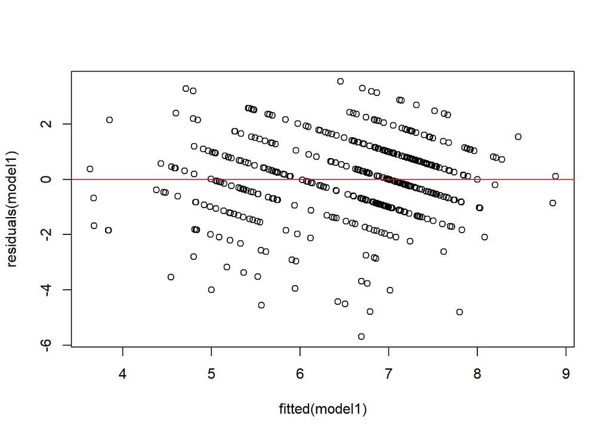

```r
# Alternatively, you can create each diagnostic plot separately:
# Residuals vs Fitted
plot(residuals(model1) ~ fitted(model1))
abline(h = 0, col = "red")
```

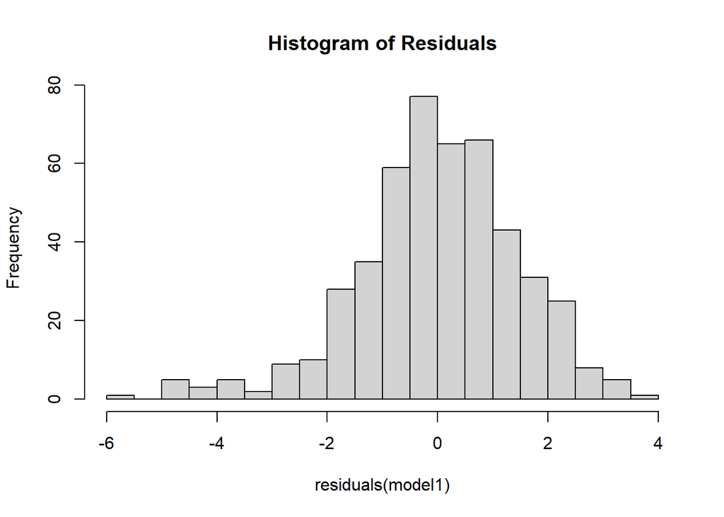

```r
# Histogram of Residuals
hist(residuals(model1), breaks = "FD", main = "Histogram of Residuals")
```

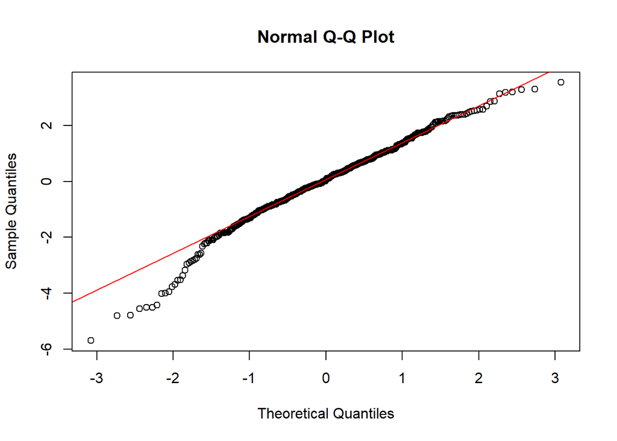

```r
# Q-Q Plot of Residuals
qqnorm(residuals(model1))
qqline(residuals(model1), col = "red")
```

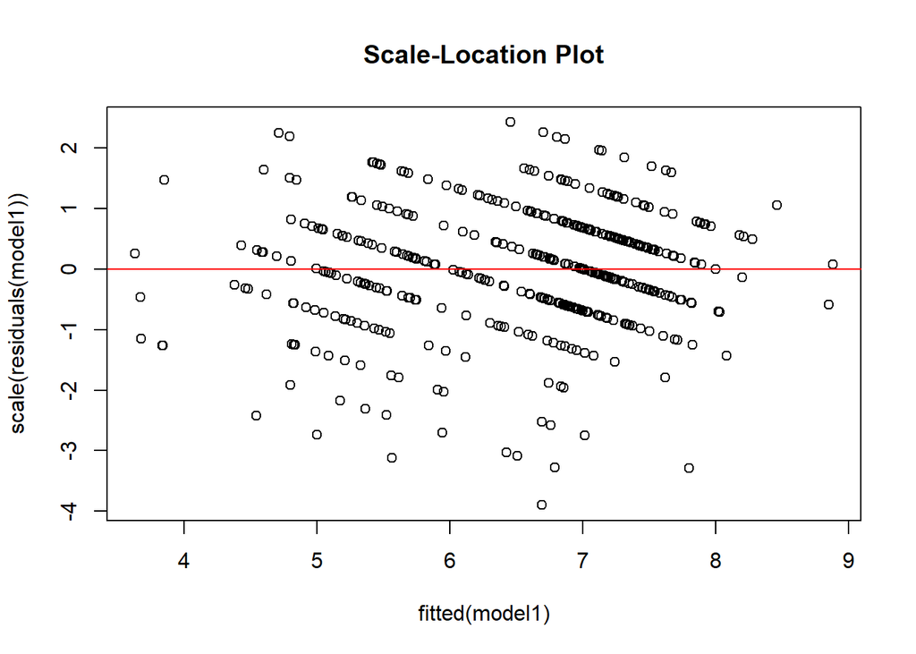

```r
# Scale-Location Plot (Spread vs Level)
plot(fitted(model1), scale(residuals(model1)), main = "Scale-Location Plot")
abline(h = 0, col = "red")
```

```r
model2 <- lmer(MOOD ~  SLEEP_COUNT + STEP_COUNT + (1 | DAYOFWEEK), data = df_MOOD_sleep_polar_MOOD_NZ_norm)
```

```
## boundary (singular) fit: see help('isSingular')
```

```r
summary(model2)
```

```
## Linear mixed model fit by REML. t-tests use Satterthwaite's method [
## lmerModLmerTest]
## Formula: MOOD ~ SLEEP_COUNT + STEP_COUNT + (1 | DAYOFWEEK)
##    Data: df_MOOD_sleep_polar_MOOD_NZ_norm
##
## REML criterion at convergence: 1925
##
## Scaled residuals:
##     Min      1Q  Median      3Q     Max
## -3.3791 -0.5836  0.1330  0.7516  2.1617
##
## Random effects:
##  Groups    Name        Variance Std.Dev.
##  DAYOFWEEK (Intercept) 0.000    0.0
##  Residual              3.241    1.8
## Number of obs: 478, groups:  DAYOFWEEK, 7
##
## Fixed effects:
##              Estimate Std. Error        df t value Pr(>|t|)
## (Intercept)   6.50418    0.08234 475.00000  78.992  < 2e-16 ***
## SLEEP_COUNT  -0.02427    0.08369 475.00000  -0.290  0.77190
## STEP_COUNT    0.26216    0.08369 475.00000   3.133  0.00184 **
## ---
## Signif. codes:  0 '***' 0.001 '**' 0.01 '*' 0.05 '.' 0.1 ' ' 1
##
## Correlation of Fixed Effects:
##             (Intr) SLEEP_
## SLEEP_COUNT 0.000
## STEP_COUNT  0.000  0.173
## optimizer (nloptwrap) convergence code: 0 (OK)
## boundary (singular) fit: see help('isSingular')
```

```r
confint(model2)
```

```
## Computing profile confidence intervals ...
```

```
##                   2.5 %    97.5 %
## .sig01       0.00000000 0.2815148
## .sigma       1.68654611 1.9146195
## (Intercept)  6.34298385 6.6653843
## SLEEP_COUNT -0.18811345 0.1395658
## STEP_COUNT   0.09832461 0.4260039
```

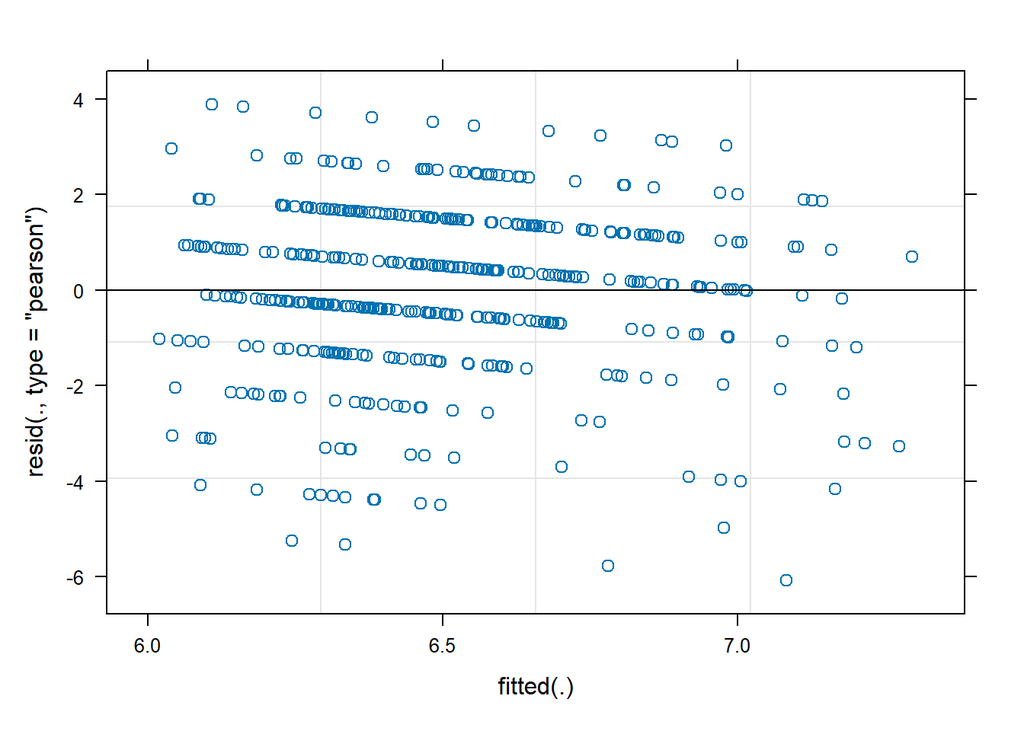

```r
plot(model2)
```

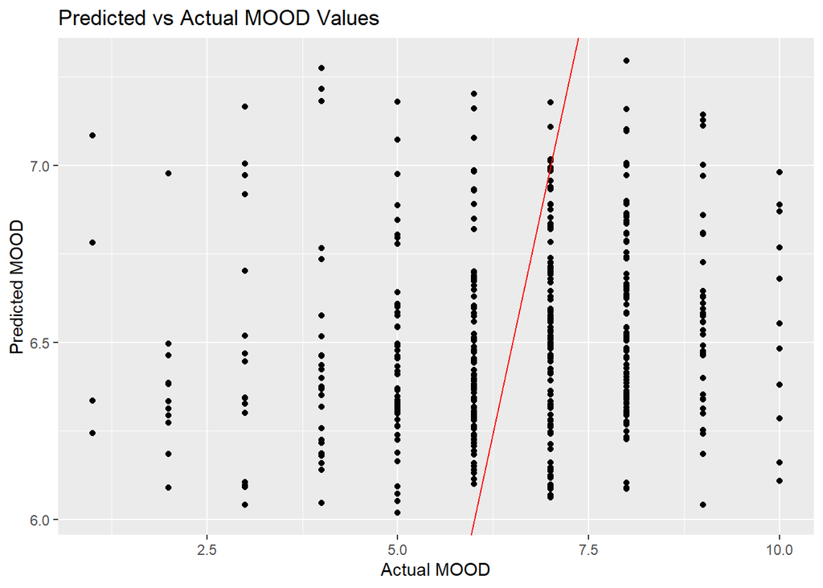

```r
# Assuming that MOOD is a column in your data frame with actual values
df_MOOD_sleep_polar_MOOD_NZ_norm$predicted_MOOD <- predict(model2, re.form = NA)

ggplot(df_MOOD_sleep_polar_MOOD_NZ_norm, aes(x = MOOD, y = predicted_MOOD)) +
  geom_point() +
  geom_abline(intercept = 0, slope = 1, color = "red") +
  xlab("Actual MOOD") +
  ylab("Predicted MOOD") +
  ggtitle("Predicted vs Actual MOOD Values")
```

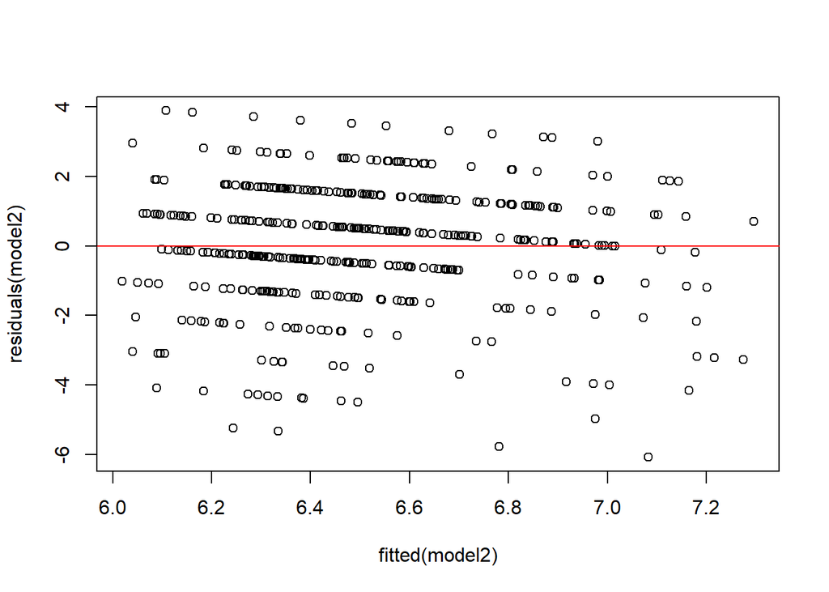

```r
# Alternatively, you can create each diagnostic plot separately:
# Residuals vs Fitted
plot(residuals(model2) ~ fitted(model2))
abline(h = 0, col = "red")
```

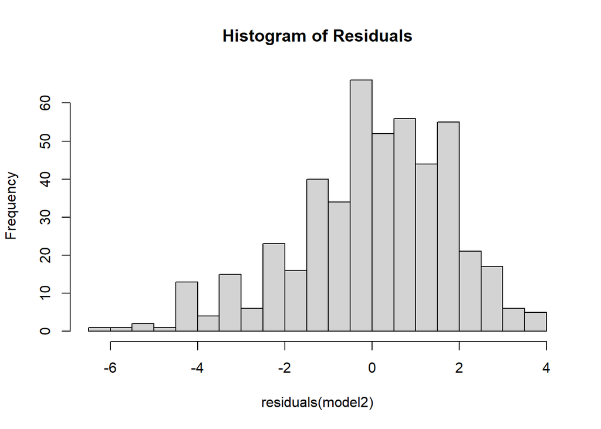

```r
# Histogram of Residuals
hist(residuals(model2), breaks = "FD", main = "Histogram of Residuals")
```

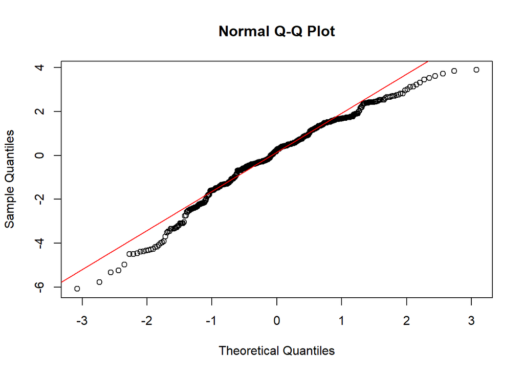

```r
# Q-Q Plot of Residuals
qqnorm(residuals(model2))
qqline(residuals(model2), col = "red")
```

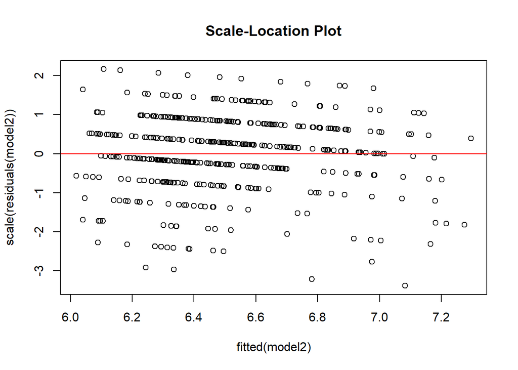

```r
# Scale-Location Plot (Spread vs Level)
plot(fitted(model2), scale(residuals(model2)), main = "Scale-Location Plot")
abline(h = 0, col = "red")
```

```r
model3 <- lmer(MOOD ~ DEEP_MIN + STEP_COUNT + (1 | STUDY_PRTCPT_ID), data = df_MOOD_sleep_polar_MOOD_NZ_norm)

summary(model3)
```

```
## Linear mixed model fit by REML. t-tests use Satterthwaite's method [
## lmerModLmerTest]
## Formula: MOOD ~ DEEP_MIN + STEP_COUNT + (1 | STUDY_PRTCPT_ID)
##    Data: df_MOOD_sleep_polar_MOOD_NZ_norm
##
## REML criterion at convergence: 1795.8
##
## Scaled residuals:
##     Min      1Q  Median      3Q     Max
## -3.8387 -0.5357  0.0464  0.6166  2.3162
##
## Random effects:
##  Groups          Name        Variance Std.Dev.
##  STUDY_PRTCPT_ID (Intercept) 1.495    1.223
##  Residual                    2.222    1.491
## Number of obs: 478, groups:  STUDY_PRTCPT_ID, 25
##
## Fixed effects:
##              Estimate Std. Error        df t value Pr(>|t|)
## (Intercept)   6.69615    0.27180  20.68937  24.636  < 2e-16 ***
## DEEP_MIN      0.11943    0.07106 462.46912   1.681   0.0935 .
## STEP_COUNT    0.37489    0.08321 474.83605   4.505 8.36e-06 ***
## ---
## Signif. codes:  0 '***' 0.001 '**' 0.01 '*' 0.05 '.' 0.1 ' ' 1
##
## Correlation of Fixed Effects:
##            (Intr) DEEP_M
## DEEP_MIN   0.001
## STEP_COUNT 0.023  0.036
```

```r
confint(model3)
```

```
## Computing profile confidence intervals ...
```

```
##                   2.5 %    97.5 %
## .sig01       0.84292462 1.7221687
## .sigma       1.39577515 1.5903035
## (Intercept)  6.15900959 7.2477402
## DEEP_MIN    -0.01955644 0.2589804
## STEP_COUNT   0.21135257 0.5374599
```

```r
model4 <-lm(formula = MOOD ~ DEEP_MIN + LIGHT_MIN + REM_MIN + WAKE_MIN, data = df_MOOD_sleep_polar_MOOD_NZ_norm)
summary(model4)
```

```
##
## Call:
## lm(formula = MOOD ~ DEEP_MIN + LIGHT_MIN + REM_MIN + WAKE_MIN,
##     data = df_MOOD_sleep_polar_MOOD_NZ_norm)
##
## Residuals:
##     Min      1Q  Median      3Q     Max
## -5.7863 -1.0393  0.1807  1.2356  4.1041
##
## Coefficients:
##             Estimate Std. Error t value Pr(>|t|)
## (Intercept)  6.50418    0.08163  79.676  < 2e-16 ***
## DEEP_MIN     0.24767    0.09497   2.608   0.0094 **
## LIGHT_MIN    0.28279    0.11311   2.500   0.0128 *
## REM_MIN      0.03111    0.10198   0.305   0.7605
## WAKE_MIN    -0.45617    0.11269  -4.048 6.03e-05 ***
## ---
## Signif. codes:  0 '***' 0.001 '**' 0.01 '*' 0.05 '.' 0.1 ' ' 1
##
## Residual standard error: 1.785 on 473 degrees of freedom
## Multiple R-squared:  0.04247,    Adjusted R-squared:  0.03437
## F-statistic: 5.245 on 4 and 473 DF,  p-value: 0.0003851
```

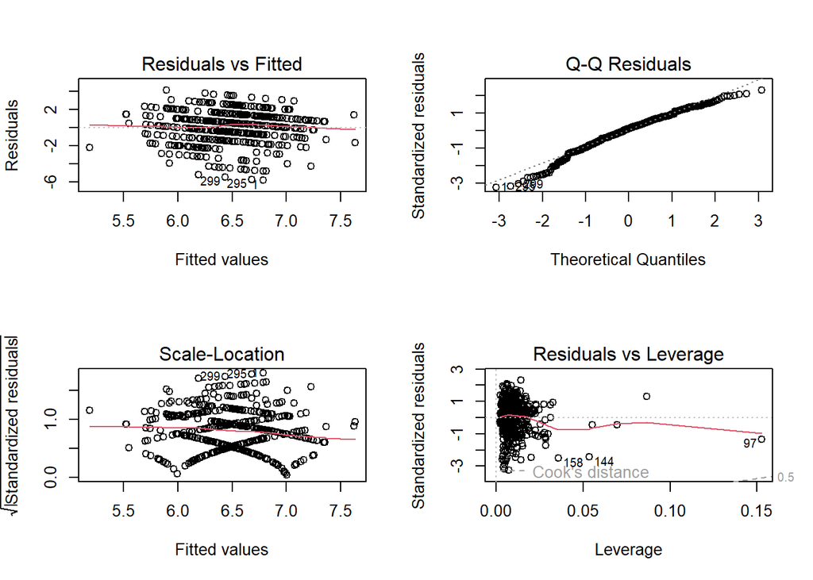

```r
par(mfrow=c(2,2))
plot(model4)
```

```r
residuals4 <- residuals(model4)
fitted_values <- fitted(model4)
```

```r
model4_mem <-lmer(MOOD ~ DEEP_MIN + LIGHT_MIN + REM_MIN + WAKE_MIN + (1 | STUDY_PRTCPT_ID),    data = df_MOOD_sleep_polar_MOOD_NZ_norm)
summary(model4_mem)
```

```
## Linear mixed model fit by REML. t-tests use Satterthwaite's method [
## lmerModLmerTest]
## Formula:
## MOOD ~ DEEP_MIN + LIGHT_MIN + REM_MIN + WAKE_MIN + (1 | STUDY_PRTCPT_ID)
##    Data: df_MOOD_sleep_polar_MOOD_NZ_norm
##
## REML criterion at convergence: 1817.6
##
## Scaled residuals:
##     Min      1Q  Median      3Q     Max
## -3.9304 -0.5190  0.0507  0.6498  2.2313
##
## Random effects:
##  Groups          Name        Variance Std.Dev.
##  STUDY_PRTCPT_ID (Intercept) 1.436    1.199
##  Residual                    2.319    1.523
## Number of obs: 478, groups:  STUDY_PRTCPT_ID, 25
##
## Fixed effects:
##               Estimate Std. Error         df t value Pr(>|t|)
## (Intercept)   6.636141   0.268597  20.291960  24.707   <2e-16 ***
## DEEP_MIN      0.149201   0.087807 460.444094   1.699    0.090 .
## LIGHT_MIN    -0.178443   0.125828 472.996373  -1.418    0.157
## REM_MIN       0.002725   0.093371 470.092202   0.029    0.977
## WAKE_MIN      0.023379   0.122758 472.998022   0.190    0.849
## ---
## Signif. codes:  0 '***' 0.001 '**' 0.01 '*' 0.05 '.' 0.1 ' ' 1
##
## Correlation of Fixed Effects:
##           (Intr) DEEP_M LIGHT_ REM_MI
## DEEP_MIN  -0.027
## LIGHT_MIN  0.039  0.052
## REM_MIN    0.020 -0.385 -0.225
## WAKE_MIN   0.000 -0.259 -0.635 -0.059
```